# Survival analysis and table 0.1

2024-01-09

## Loading, checking and consolidating data

```
## tibble [1,796 × 10] (S3: tbl_df/tbl/data.frame)
##  $ Item               : num [1:1796] 10 263 265 267 268 269 270 271 277 279 ...
##  $ GEBURT             : POSIXct[1:1796], format: "1959-01-13" "1938-08-15" ...
##  $ STERBEDAT          : POSIXct[1:1796], format: NA NA ...
##  $ STERBEDAT_unbekant : num [1:1796] NA NA NA NA NA NA NA 1 NA NA ...
##  $ STERBEDAT_only_year: num [1:1796] NA NA NA NA NA NA NA NA 1 NA ...
##  $ LAST_FU            : POSIXct[1:1796], format: "2020-12-03 08:32:17" NA ...
##  $ LAST_FU_only_year  : num [1:1796] NA NA NA NA NA NA NA NA NA NA ...
##  $ OP_DATUM           : POSIXct[1:1796], format: "2016-05-02" "2011-02-03" ...
##  $ REOP_DAT           : POSIXct[1:1796], format: NA NA ...
##  $ FUEcho_DATUM       : POSIXct[1:1796], format: "2020-12-03" NA ...
```

Let’s impute the data where STERBEDAT = “unbekant”Let’s count the last visit as the last of the dates (reoperation, lastfu, fueсho and death)

```
##                       Min.                    1st Qu.
## "2011-04-13 00:00:00.0000" "2016-12-10 05:53:35.0000"
##                     Median                       Mean
## "2021-07-26 00:00:00.0000" "2019-03-14 09:50:22.7331"
##                    3rd Qu.                       Max.
## "2021-08-05 00:00:00.0000" "2022-03-03 00:00:00.0000"
##                       NA's
##                      "102"
```

Check: 1. Are there any patients whose date of death is less than the date of their last visit?

2. Are there any patients with the date of the last foluap before surgery?
3. Are there any patients we don’t know about the fact of death who do not have FollowUp?

Let’s look at these patients:

```
## # A tibble: 97 × 6
##    Case_Num OS_Event Sx_Date             OS_Date             Last_FU_upd
##       <dbl>    <dbl> <dttm>              <dttm>              <dttm>
##  1      263        0 2011-02-03 00:00:00 NA                  NA
##  2      270        0 2011-02-15 00:00:00 NA                  NA
##  3      285        0 2011-03-08 00:00:00 NA                  NA
##  4      286        0 2011-03-10 00:00:00 NA                  NA
##  5      289        0 2011-03-16 00:00:00 NA                  NA
##  6      300        1 2011-04-05 00:00:00 2011-05-19 00:00:00 2016-03-23 00:00:00
##  7      312        0 2011-04-26 00:00:00 NA                  NA
##  8      319        0 2011-05-09 00:00:00 NA                  NA
##  9      327        0 2011-05-17 00:00:00 NA                  NA
## 10      329        0 2011-05-19 00:00:00 NA                  NA
## # ℹ 87 more rows
## # ℹ 1 more variable: Date_check <chr>
```

We exclude patients for whom it is impossible to determine the date of the FollowUp

Let’s find the maximum date, which we will take as the database closure date

```
## [1] "2022-03-03 UTC"
```

Let’s calculate the time until death and impute the data to those whose death we know about, but do not know the date

```
## [1] 106.5
```

Where there is no last visit and the date of death is unknown, we impute the median time to death, provided that the patient is known to have died.

Where there is a last visit, but the date of death is unknown, we substitute the midpoint of the time between the patient’s last visit and the “closing of the database” (the most recent visit of all)

Now let’s check whether all situations can be processed in this way

```
## [1] 0
```

## Preparing data for survival analysis

The observation statute is already there, the variable “OS_Event” It is necessary to calculate the duration of observation for each subject

Let’s calculate the duration only for those who are not dead, because for the dead it has already been calculated

```
## # A tibble: 0 × 6
## # ℹ 6 variables: Case_Num <dbl>, OS_Event <dbl>, Sx_Date <dttm>,
## #   OS_Date <dttm>, Last_FU_upd <dttm>, Date_check <chr>
```

Combine the duration to death with the duration to last follow-up

Save the dataset with patients for whom the outcome/duration is known

## Baseline values of demographic and anthropometric characteristics

Let’s select the variables we are interested in

The value of characteristics at time point 0 in the groups of known upsizing and unknown upsizing

[output not shown]

| **Characteristic** | **0**, N = 473<sup>1</sup> | **1**, N = 973<sup>1</sup> | **NA**, N = 253<sup>1</sup> | **p-value**<sup>2</sup> |
| --- | --- | --- | --- | --- |
| Age | 69 (62, 76) | 71 (64, 76) | 72 (68, 77) | <0.001 |
| BMI | 27.8 (25.0, 31.3) | 27.9 (25.1, 31.1) | 28.1 (24.9, 31.5) | >0.9 |
| Unknown | 0 | 0 | 1 |  |
| Gender |  |  |  | 0.050 |
| 1 | 386 (82%) | 773 (79%) | 187 (74%) |  |
| 2 | 87 (18%) | 200 (21%) | 66 (26%) |  |
| STS | 2.2 (1.3, 4.1) | 2.4 (1.5, 4.1) | 2.5 (1.6, 5.0) | 0.037 |
| Prosthesis_Anat_Aort_Valve |  |  |  | 0.2 |
| 0 | 357 (75%) | 739 (76%) | 205 (81%) |  |
| 1 | 115 (24%) | 234 (24%) | 48 (19%) |  |
| 2 | 1 (0.2%) | 0 (0%) | 0 (0%) |  |
| Pre_Bicuspid |  |  |  |  |
| 0 | 355 (75%) | 739 (76%) | 203 (80%) |  |
| 1 | 115 (24%) | 233 (24%) | 48 (19%) |  |
| 9 | 2 (0.4%) | 1 (0.1%) | 2 (0.8%) |  |
| Unknown | 1 | 0 | 0 |  |
| Prosthesis_Anat_Size | 25.00 (25.00, 27.00) | 23.00 (23.00, 25.00) | NA (NA, NA) | <0.001 |
| Unknown | 0 | 0 | 253 |  |
| Sx_Date | 2011-04-18 to 2021-08-20 | 2011-09-07 to 2021-10-26 | 2011-02-08 to 2021-08-26 | <0.001 |
| OS_Event | 95 (20%) | 171 (18%) | 84 (33%) | <0.001 |
| DUR | 964 (41, 1,932) | 1,108 (107, 2,096) | 1,044 (16, 3,394) | 0.026 |

<sup>1</sup> Median (IQR); n (%); Range  
<sup>2</sup> Kruskal-Wallis rank sum test; Pearson’s Chi-squared test; Fisher’s exact test

Value of characteristics at time point 0 only in groups of known upsizing

[output not shown]

| **Characteristic** | **0**, N = 473<sup>1</sup> | **1**, N = 973<sup>1</sup> | **p-value**<sup>2</sup> |
| --- | --- | --- | --- |
| Age | 69 (62, 76) | 71 (64, 76) | 0.009 |
| BMI | 27.8 (25.0, 31.3) | 27.9 (25.1, 31.1) | >0.9 |
| Gender |  |  | 0.3 |
| 1 | 386 (82%) | 773 (79%) |  |
| 2 | 87 (18%) | 200 (21%) |  |
| NYHA_Heart_Fail_Class |  |  | 0.2 |
| 0 | 26 (5.5%) | 29 (3.0%) |  |
| 1 | 31 (6.6%) | 79 (8.1%) |  |
| 2 | 110 (23%) | 236 (24%) |  |
| 3 | 267 (56%) | 546 (56%) |  |
| 4 | 39 (8.2%) | 83 (8.5%) |  |
| STS | 2.2 (1.3, 4.1) | 2.4 (1.5, 4.1) | 0.2 |
| Prosthesis_Anat_Aort_Valve |  |  | 0.4 |
| 0 | 357 (75%) | 739 (76%) |  |
| 1 | 115 (24%) | 234 (24%) |  |
| 2 | 1 (0.2%) | 0 (0%) |  |
| Pre_Bicuspid |  |  | 0.4 |
| 0 | 355 (75%) | 739 (76%) |  |
| 1 | 115 (24%) | 233 (24%) |  |
| 9 | 2 (0.4%) | 1 (0.1%) |  |
| Unknown | 1 | 0 |  |
| Prosthesis_Anat_Size | 25.00 (25.00, 27.00) | 23.00 (23.00, 25.00) | <0.001 |
| Sx_Date | 2011-04-18 to 2021-08-20 | 2011-09-07 to 2021-10-26 | 0.11 |
| OS_Event | 95 (20%) | 171 (18%) | 0.2 |
| DUR | 964 (41, 1,932) | 1,108 (107, 2,096) | 0.050 |
| Sx_Urgency |  |  | 0.2 |
| 1 | 339 (72%) | 693 (71%) |  |
| 2 | 94 (20%) | 223 (23%) |  |
| 3 | 35 (7.4%) | 50 (5.1%) |  |
| 4 | 5 (1.1%) | 7 (0.7%) |  |
| Sx_Surgeon |  |  |  |
| Dr. E. Nooh | 2 (0.4%) | 1 (0.1%) |  |
| Dr. med. C. Struening | 13 (2.7%) | 38 (3.9%) |  |
| Dr. med. J. Oczko | 5 (1.1%) | 20 (2.1%) |  |
| Dr. med. S. Tkebuchava | 6 (1.3%) | 2 (0.2%) |  |
| Dr. med. W. Bothe | 9 (1.9%) | 29 (3.0%) |  |
| I. Valchanov | 1 (0.2%) | 0 (0%) |  |
| Ltd. OÄ Dr. med. G. Färber | 24 (5.1%) | 136 (14%) |  |
| NA | 0 (0%) | 1 (0.1%) |  |
| OA Dr. med. H. Kirov | 16 (3.4%) | 36 (3.7%) |  |
| OA Dr. med. M. Breuer | 29 (6.1%) | 20 (2.1%) |  |
| OA Dr. med. M. Diab | 96 (20%) | 160 (16%) |  |
| OA Dr. med. P. Krieg | 3 (0.6%) | 1 (0.1%) |  |
| OA Dr. med. S. Bargenda | 33 (7.0%) | 38 (3.9%) |  |
| OA Dr. med. T. Sandhaus | 64 (14%) | 85 (8.7%) |  |
| P. Amorim | 3 (0.6%) | 1 (0.1%) |  |
| PD Dr. med. M. Diab | 1 (0.2%) | 0 (0%) |  |
| PD Dr. med. M. Richter | 57 (12%) | 194 (20%) |  |
| Prof. Dr. med. T. Doenst | 108 (23%) | 211 (22%) |  |
| Y. Essa | 3 (0.6%) | 0 (0%) |  |

<sup>1</sup> Median (IQR); n (%); Range  
<sup>2</sup> Wilcoxon rank sum test; Pearson’s Chi-squared test; Fisher’s exact test

Formatted table

| **Characteristic** | **Anatomical_Size**, N = 473<sup>1</sup> | **UP_size**, N = 973<sup>1</sup> | **p-value**<sup>2</sup> |
| --- | --- | --- | --- |
| Age | 69 (62, 76) | 71 (64, 76) | 0.003 |
| BMI | 27.8 (25.0, 31.3) | 27.9 (25.1, 31.1) | >0.9 |
| Gender |  |  | 0.3 |
| female | 87 (18%) | 200 (21%) |  |
| male | 386 (82%) | 773 (79%) |  |
| NYHA_Heart_Fail_Class |  |  | >0.9 |
| 0-2 | 167 (35%) | 344 (35%) |  |
| 3-4 | 306 (65%) | 629 (65%) |  |
| STS | 2.2 (1.3, 4.1) | 2.4 (1.5, 4.1) | 0.2 |
| Prosthesis_Anat_Aort_Valve |  |  | >0.9 |
| 2x | 115 (24%) | 234 (24%) |  |
| 3x | 358 (76%) | 739 (76%) |  |
| Urgency |  |  | 0.9 |
| Elective surgery | 339 (72%) | 693 (71%) |  |
| Urgent surgery | 134 (28%) | 280 (29%) |  |
| Prosthesis_Anat_Size | 25.00 (25.00, 27.00) | 23.00 (23.00, 25.00) | <0.001 |
| Surgeon |  |  | <0.001 |
| GF | 24 (5.1%) | 136 (14%) |  |
| MD | 96 (20%) | 160 (16%) |  |
| MR | 57 (12%) | 194 (20%) |  |
| other | 124 (26%) | 187 (19%) |  |
| TD | 108 (23%) | 211 (22%) |  |
| TS | 64 (14%) | 85 (8.7%) |  |

<sup>1</sup> Median (IQR); n (%)  
<sup>2</sup> Welch Two Sample t-test; Pearson’s Chi-squared test

## Relationship of the main variables of the analysis

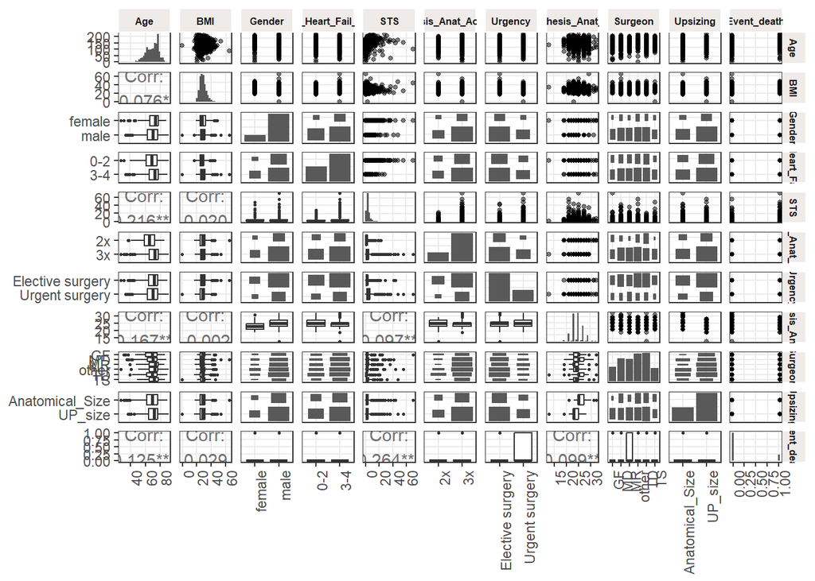

## Survival analysis

Crude model KM plot

```
##              quantile.25 quantile.75 lower.25 lower.75 upper.25 upper.75
## Upsizing=No     5.820671          NA 4.698152       NA 7.748118       NA
## Upsizing=Yes    6.841889          NA 5.919233       NA 8.306639       NA
```

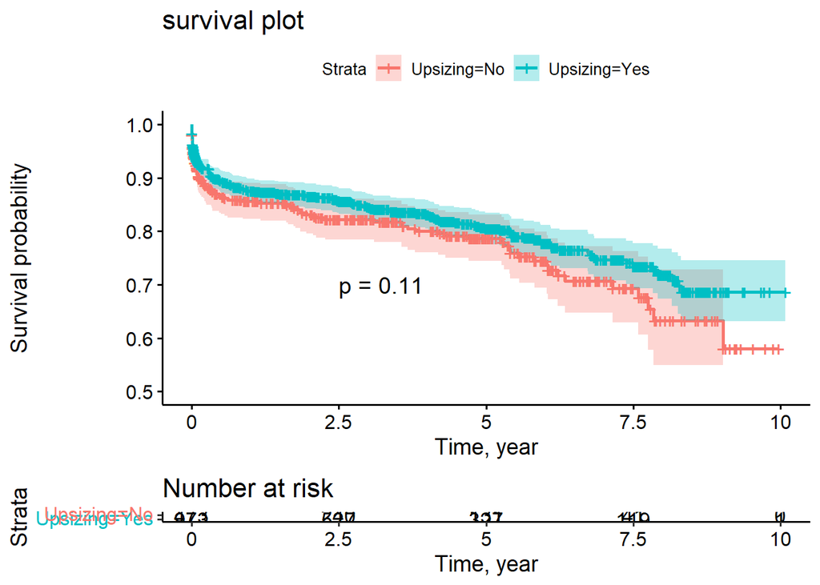

```
## Call:
## coxph(formula = surv_object ~ Upsizing, data = df_surv_known_tmp2)
##
##                coef exp(coef) se(coef)      z     p
## UpsizingYes -0.2033    0.8160   0.1281 -1.587 0.112
##
## Likelihood ratio test=2.47  on 1 df, p=0.1162
## n= 1446, number of events= 266
```

| **Characteristic** | **HR**<sup>1</sup> | **95% CI**<sup>1</sup> | **p-value** |
| --- | --- | --- | --- |
| Upsizing |  |  |  |
| No | — | — |  |
| Yes | 0.82 | 0.63, 1.05 | 0.11 |

<sup>1</sup> HR = Hazard Ratio, CI = Confidence Interval

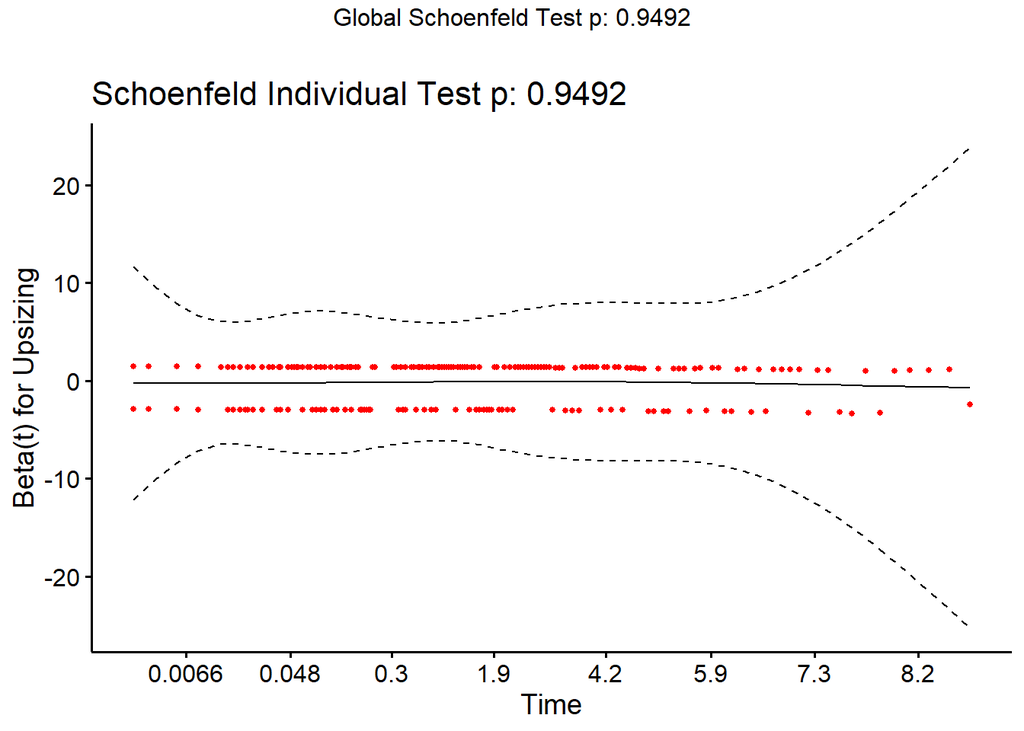

```
## Call:
## concordance.coxph(object = fit_crude)
##
## n= 1446
## Concordance= 0.5217 se= 0.01586
## concordant discordant     tied.x     tied.y    tied.xy
##      64321      52986     143611        169        231
```

Full model

```
## Call:
## coxph(formula = surv_object ~ Upsizing + Prosthesis_Anat_Size +
##     Age + Surgeon + BMI + Gender + log10(STS + 1) + NYHA_Heart_Fail_Class +
##     Prosthesis_Anat_Aort_Valve, data = df_surv_known, x = TRUE)
##
##                                   coef exp(coef)  se(coef)      z       p
## UpsizingUP_size              -0.482445  0.617272  0.148328 -3.253 0.00114
## Prosthesis_Anat_Size         -0.080005  0.923112  0.035080 -2.281 0.02257
## Age                           0.013078  1.013163  0.008114  1.612 0.10700
## SurgeonMD                    -0.200900  0.817994  0.214178 -0.938 0.34824
## SurgeonMR                     0.075629  1.078562  0.211193  0.358 0.72027
## Surgeonother                 -0.672638  0.510360  0.230712 -2.915 0.00355
## SurgeonTD                    -0.480725  0.618335  0.246298 -1.952 0.05096
## SurgeonTS                    -0.679045  0.507101  0.266282 -2.550 0.01077
## BMI                           0.033409  1.033973  0.012995  2.571 0.01014
## Gendermale                    0.304433  1.355855  0.167829  1.814 0.06969
## log10(STS + 1)                2.471288 11.837685  0.225605 10.954 < 2e-16
## NYHA_Heart_Fail_Class3-4     -0.313965  0.730544  0.142079 -2.210 0.02712
## Prosthesis_Anat_Aort_Valve3x  0.228040  1.256136  0.195020  1.169 0.24228
##
## Likelihood ratio test=188  on 13 df, p=< 2.2e-16
## n= 1446, number of events= 266
```

| **Characteristic** | **HR**<sup>1</sup> | **95% CI**<sup>1</sup> | **p-value** |
| --- | --- | --- | --- |
| Upsizing |  |  |  |
| Anatomical_Size | — | — |  |
| UP_size | 0.62 | 0.46, 0.83 | 0.001 |
| Prosthesis_Anat_Size | 0.92 | 0.86, 0.99 | 0.023 |
| Age | 1.01 | 1.00, 1.03 | 0.11 |
| Surgeon |  |  |  |
| GF | — | — |  |
| MD | 0.82 | 0.54, 1.24 | 0.3 |
| MR | 1.08 | 0.71, 1.63 | 0.7 |
| other | 0.51 | 0.32, 0.80 | 0.004 |
| TD | 0.62 | 0.38, 1.00 | 0.051 |
| TS | 0.51 | 0.30, 0.85 | 0.011 |
| BMI | 1.03 | 1.01, 1.06 | 0.010 |
| Gender |  |  |  |
| female | — | — |  |
| male | 1.36 | 0.98, 1.88 | 0.070 |
| log10(STS + 1) | 11.8 | 7.61, 18.4 | <0.001 |
| NYHA_Heart_Fail_Class |  |  |  |
| 0-2 | — | — |  |
| 3-4 | 0.73 | 0.55, 0.97 | 0.027 |
| Prosthesis_Anat_Aort_Valve |  |  |  |
| 2x | — | — |  |
| 3x | 1.26 | 0.86, 1.84 | 0.2 |

<sup>1</sup> HR = Hazard Ratio, CI = Confidence Interval

```
##                              chisq df    p
## Upsizing                   0.20708  1 0.65
## Prosthesis_Anat_Size       0.38139  1 0.54
## Age                        0.07066  1 0.79
## Surgeon                    3.51245  5 0.62
## BMI                        0.42697  1 0.51
## Gender                     0.38539  1 0.53
## log10(STS + 1)             0.00483  1 0.94
## NYHA_Heart_Fail_Class      0.50807  1 0.48
## Prosthesis_Anat_Aort_Valve 2.51856  1 0.11
## GLOBAL                     8.31145 13 0.82
```

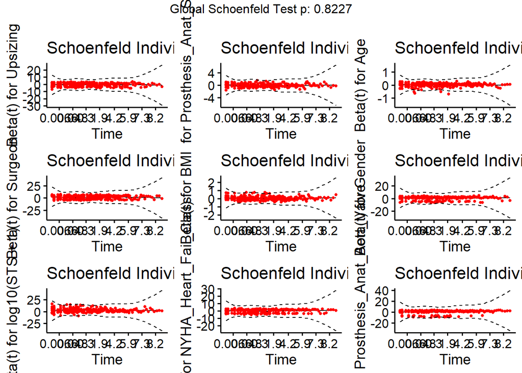

```
## Call:
## concordance.coxph(object = fit_full)
##
## n= 1446
## Concordance= 0.7219 se= 0.01673
## concordant discordant     tied.x     tied.y    tied.xy
##     188344      72574          0        400          0
```

```
##                                GVIF Df GVIF^(1/(2*Df))
## Upsizing                   1.338255  1        1.156830
## Prosthesis_Anat_Size       1.515035  1        1.230867
## Age                        1.170644  1        1.081963
## Surgeon                    1.358945  5        1.031146
## BMI                        1.065873  1        1.032411
## Gender                     1.192879  1        1.092190
## log10(STS + 1)             1.282118  1        1.132306
## NYHA_Heart_Fail_Class      1.151023  1        1.072858
## Prosthesis_Anat_Aort_Valve 1.153650  1        1.074081
```

Two minimum reasonable models

```
## Analysis of Deviance Table
##  Cox model: response is  surv_object
##  Model 1: ~ Upsizing + Prosthesis_Anat_Size + Age
##  Model 2: ~ Upsizing + Prosthesis_Anat_Size + Age + Surgeon
##    loglik  Chisq Df Pr(>|Chi|)
## 1 -1775.0
## 2 -1757.6 34.856  5  1.608e-06 ***
## ---
## Signif. codes:  0 '***' 0.001 '**' 0.01 '*' 0.05 '.' 0.1 ' ' 1
```

Test minimal model

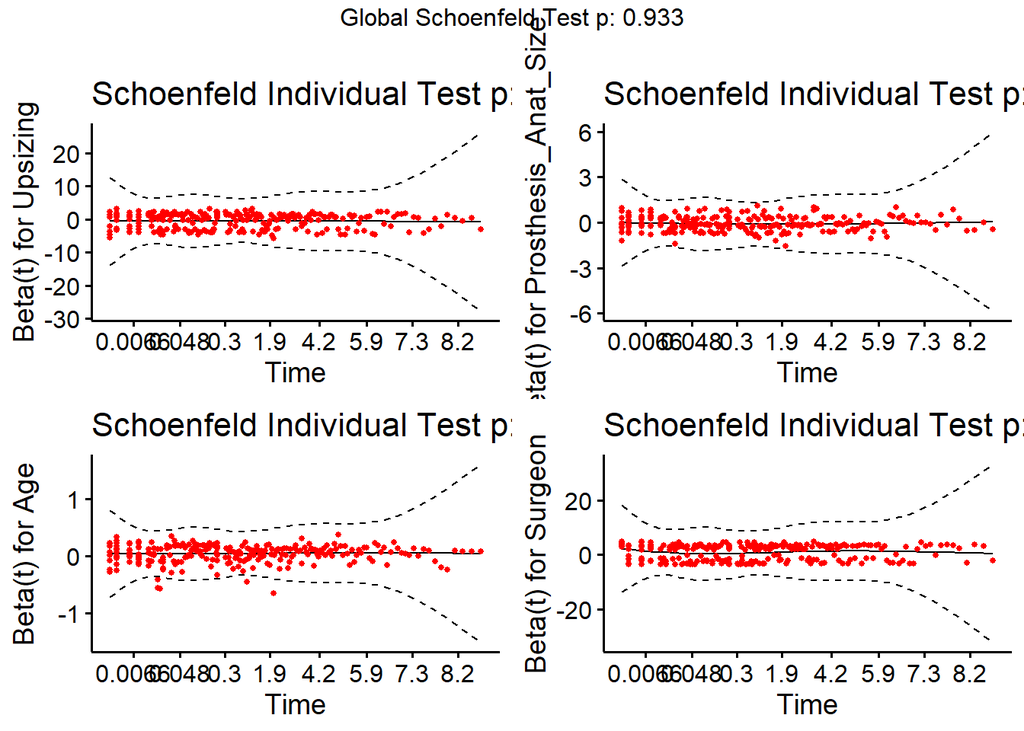

```
## Call:
## concordance.coxph(object = fit_mini2)
##
## n= 1446
## Concordance= 0.6478 se= 0.01757
## concordant discordant     tied.x     tied.y    tied.xy
##     168898      91774        246        400          0
```

Optimal model

| **Characteristic** | **HR**<sup>1</sup> | **95% CI**<sup>1</sup> | **p-value** |
| --- | --- | --- | --- |
| Upsizing |  |  |  |
| Anatomical_Size | — | — |  |
| UP_size | 0.67 | 0.50, 0.89 | 0.006 |
| Prosthesis_Anat_Size | 0.95 | 0.89, 1.01 | 0.092 |
| Age | 1.01 | 1.0, 1.03 | 0.2 |
| Surgeon |  |  |  |
| GF | — | — |  |
| MD | 0.84 | 0.55, 1.27 | 0.4 |
| MR | 1.12 | 0.74, 1.69 | 0.6 |
| other | 0.55 | 0.35, 0.86 | 0.009 |
| TD | 0.58 | 0.36, 0.94 | 0.028 |
| TS | 0.58 | 0.34, 0.97 | 0.036 |
| log10(STS + 1) | 10.3 | 6.72, 15.6 | <0.001 |

<sup>1</sup> HR = Hazard Ratio, CI = Confidence Interval

| **Characteristic** | Univarative **HR**<sup>1</sup> | Univarative **95% CI**<sup>1</sup> | Univarative **p-value** | Adjustment_1 **HR**<sup>1</sup> | Adjustment_1 **95% CI**<sup>1</sup> | Adjustment_1 **p-value** | Adjasment_full **HR**<sup>1</sup> | Adjasment_full **95% CI**<sup>1</sup> | Adjasment_full **p-value** |
| --- | --- | --- | --- | --- | --- | --- | --- | --- | --- |
| Upsizing |  |  |  |  |  |  |  |  |  |
| No | — | — |  |  |  |  |  |  |  |
| Yes | 0.82 | 0.63, 1.05 | 0.11 |  |  |  |  |  |  |
| Anatomical_Size |  |  |  | — | — |  | — | — |  |
| UP_size |  |  |  | 0.60 | 0.45, 0.79 | <0.001 | 0.62 | 0.46, 0.83 | 0.001 |
| Prosthesis_Anat_Size |  |  |  | 0.93 | 0.87, 0.98 | 0.015 | 0.92 | 0.86, 0.99 | 0.023 |
| Age |  |  |  | 1.04 | 1.02, 1.06 | <0.001 | 1.01 | 1.00, 1.03 | 0.11 |
| Surgeon |  |  |  |  |  |  |  |  |  |
| GF |  |  |  | — | — |  | — | — |  |
| MD |  |  |  | 0.90 | 0.59, 1.37 | 0.6 | 0.82 | 0.54, 1.24 | 0.3 |
| MR |  |  |  | 1.09 | 0.73, 1.64 | 0.7 | 1.08 | 0.71, 1.63 | 0.7 |
| other |  |  |  | 0.46 | 0.29, 0.72 | <0.001 | 0.51 | 0.32, 0.80 | 0.004 |
| TD |  |  |  | 0.46 | 0.28, 0.74 | 0.001 | 0.62 | 0.38, 1.00 | 0.051 |
| TS |  |  |  | 0.59 | 0.35, 0.98 | 0.041 | 0.51 | 0.30, 0.85 | 0.011 |
| BMI |  |  |  |  |  |  | 1.03 | 1.01, 1.06 | 0.010 |
| Gender |  |  |  |  |  |  |  |  |  |
| female |  |  |  |  |  |  | — | — |  |
| male |  |  |  |  |  |  | 1.36 | 0.98, 1.88 | 0.070 |
| log10(STS + 1) |  |  |  |  |  |  | 11.8 | 7.61, 18.4 | <0.001 |
| NYHA_Heart_Fail_Class |  |  |  |  |  |  |  |  |  |
| 0-2 |  |  |  |  |  |  | — | — |  |
| 3-4 |  |  |  |  |  |  | 0.73 | 0.55, 0.97 | 0.027 |
| Prosthesis_Anat_Aort_Valve |  |  |  |  |  |  |  |  |  |
| 2x |  |  |  |  |  |  | — | — |  |
| 3x |  |  |  |  |  |  | 1.26 | 0.86, 1.84 | 0.2 |

<sup>1</sup> HR = Hazard Ratio, CI = Confidence Interval

Let’s test the model in more detail

```
##                              chisq df    p
## Upsizing                   0.20708  1 0.65
## Prosthesis_Anat_Size       0.38139  1 0.54
## Age                        0.07066  1 0.79
## Surgeon                    3.51245  5 0.62
## BMI                        0.42697  1 0.51
## Gender                     0.38539  1 0.53
## log10(STS + 1)             0.00483  1 0.94
## NYHA_Heart_Fail_Class      0.50807  1 0.48
## Prosthesis_Anat_Aort_Valve 2.51856  1 0.11
## GLOBAL                     8.31145 13 0.82
```

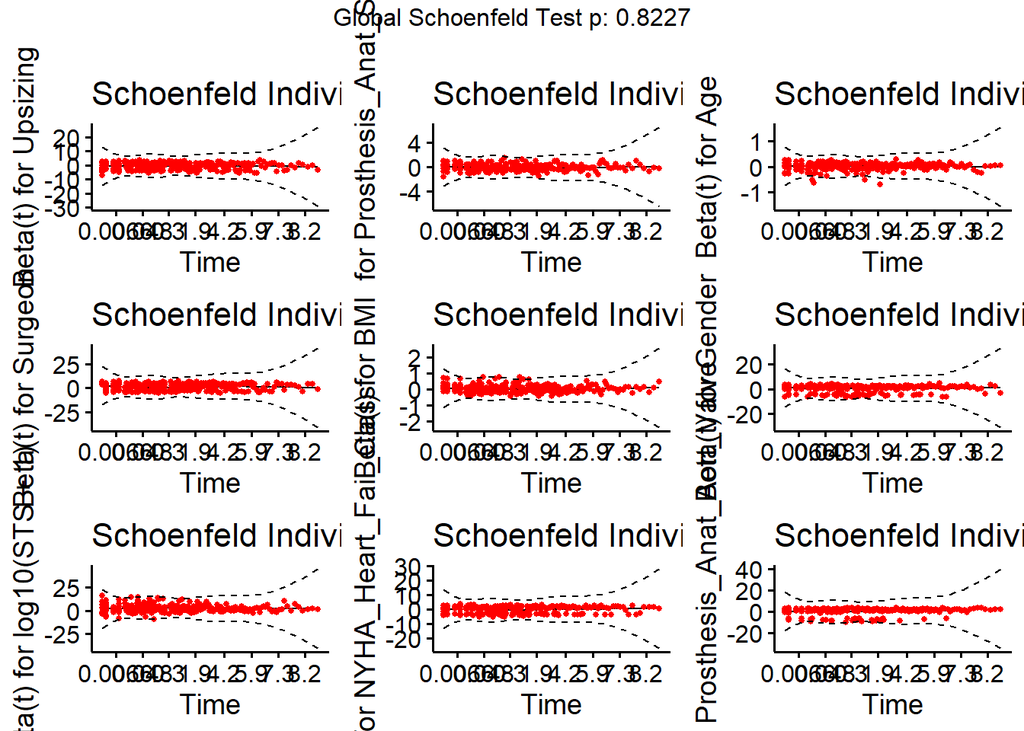

```
## Call:
## concordance.coxph(object = fit_full)
##
## n= 1446
## Concordance= 0.7219 se= 0.01673
## concordant discordant     tied.x     tied.y    tied.xy
##     188344      72574          0        400          0
```

```
## Call:
## concordance.coxph(object = fit_mini2)
##
## n= 1446
## Concordance= 0.6478 se= 0.01757
## concordant discordant     tied.x     tied.y    tied.xy
##     168898      91774        246        400          0
```

```
##                                GVIF Df GVIF^(1/(2*Df))
## Upsizing                   1.338255  1        1.156830
## Prosthesis_Anat_Size       1.515035  1        1.230867
## Age                        1.170644  1        1.081963
## Surgeon                    1.358945  5        1.031146
## BMI                        1.065873  1        1.032411
## Gender                     1.192879  1        1.092190
## log10(STS + 1)             1.282118  1        1.132306
## NYHA_Heart_Fail_Class      1.151023  1        1.072858
## Prosthesis_Anat_Aort_Valve 1.153650  1        1.074081
```

```
## Analysis of Deviance Table
##  Cox model: response is  surv_object
##  Model 1: ~ Upsizing + Prosthesis_Anat_Size + Age + Surgeon + BMI + Gender + log10(STS + 1) + NYHA_Heart_Fail_Class + Prosthesis_Anat_Aort_Valve
##  Model 2: ~ Upsizing + Prosthesis_Anat_Size + Age + Surgeon
##    loglik  Chisq Df Pr(>|Chi|)
## 1 -1701.2
## 2 -1757.6 112.69  5  < 2.2e-16 ***
## ---
## Signif. codes:  0 '***' 0.001 '**' 0.01 '*' 0.05 '.' 0.1 ' ' 1
```

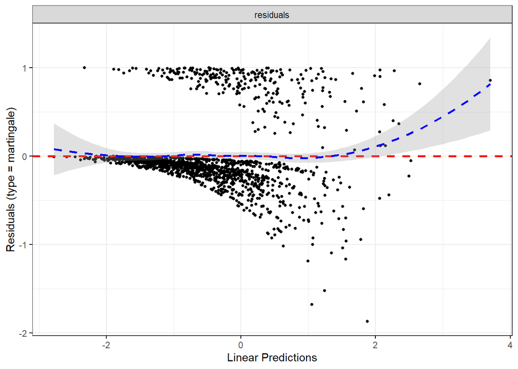

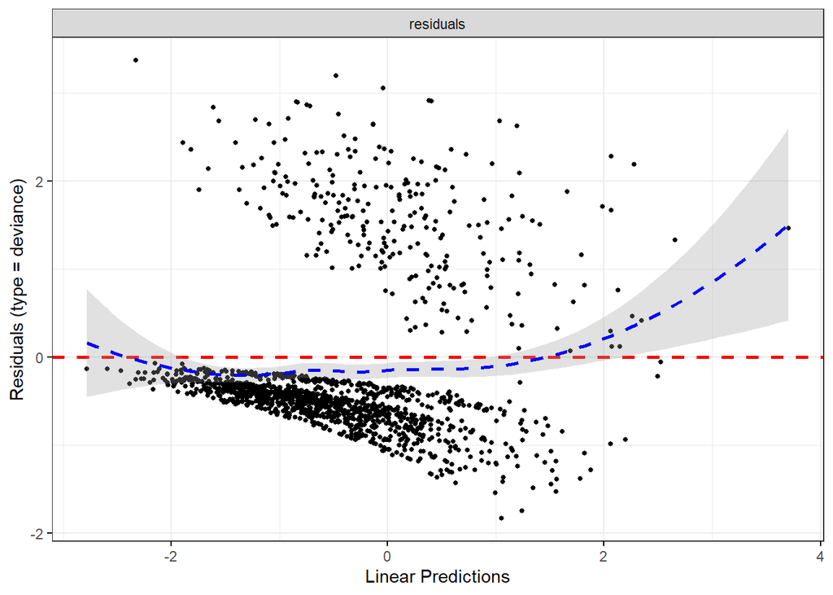

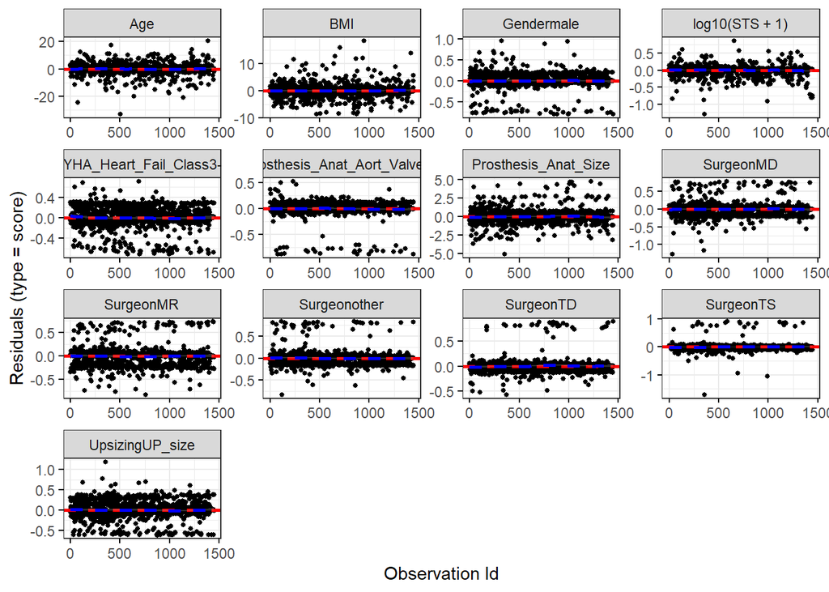

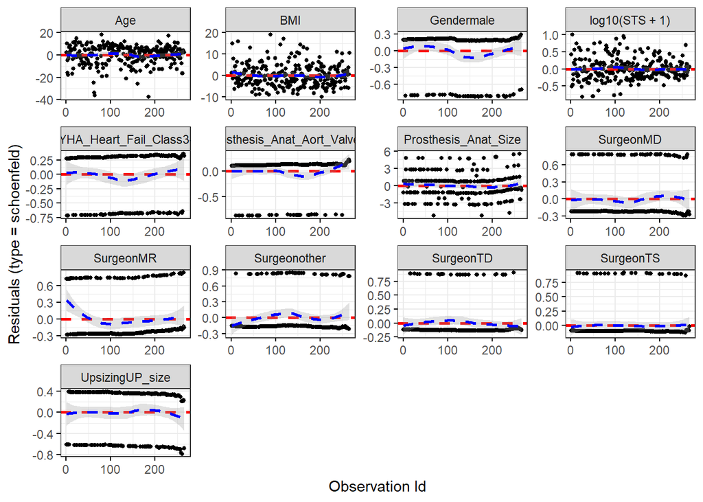

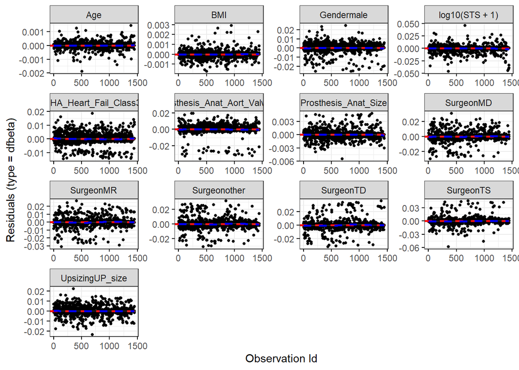

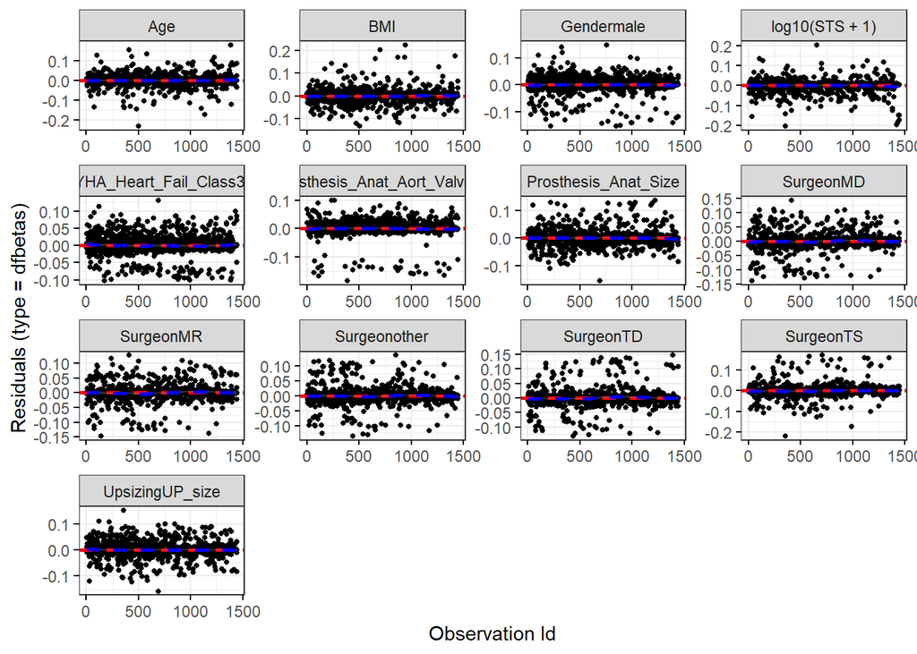

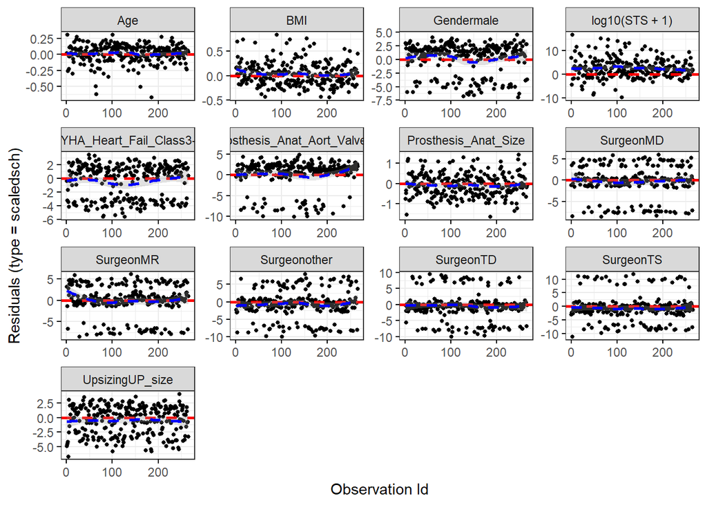

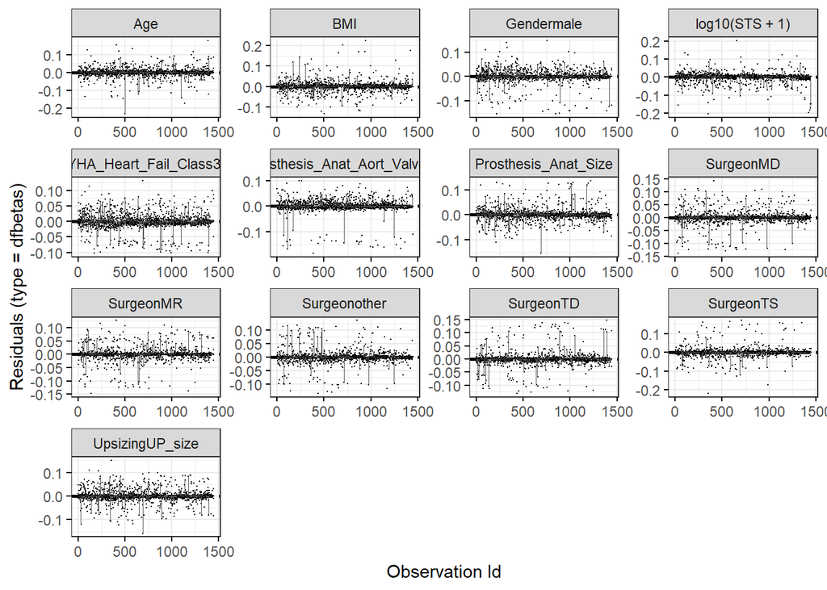

Building a Forrest Raft for a model with categories

```
## # A tibble: 7 × 7
##   term                  estimate std.error statistic  p.value conf.low conf.high
##   <chr>                    <dbl>     <dbl>     <dbl>    <dbl>    <dbl>     <dbl>
## 1 Age__70+                0.223      0.141     1.58  1.13e- 1 -0.0530      0.499
## 2 BMI__30+                0.0782     0.129     0.607 5.44e- 1 -0.174       0.331
## 3 Gender__male            0.266      0.158     1.68  9.26e- 2 -0.0441      0.577
## 4 STS__3+                 1.05       0.135     7.79  6.49e-15  0.786       1.31
## 5 Prosthesis_Anat_Aort…   0.370      0.192     1.93  5.42e- 2 -0.00668     0.747
## 6 Prosthesis_Anat_Size…  -0.576      0.183    -3.15  1.65e- 3 -0.934      -0.217
## 7 UpsizingUP_size        -0.424      0.136    -3.12  1.79e- 3 -0.690      -0.158
```

```
##                              chisq df    p
## Age__                      0.77357  1 0.38
## BMI__                      0.23989  1 0.62
## Gender__                   0.17533  1 0.68
## STS__                      1.32471  1 0.25
## Prosthesis_Anat_Aort_Valve 2.00536  1 0.16
## Prosthesis_Anat_Size__     0.05612  1 0.81
## Upsizing                   0.00541  1 0.94
## GLOBAL                     5.89201  7 0.55
```

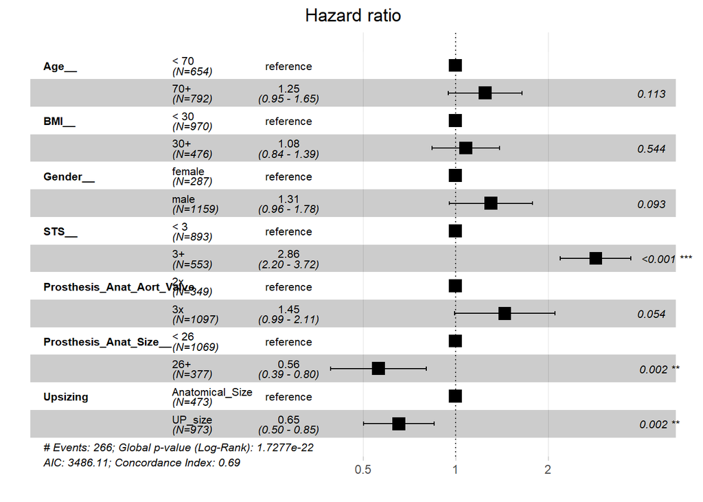

```
## # A tibble: 12 × 9
##    Subgroup_var Subgroup_level Subgroup     Up_size_Count Anathomical_size_Count
##    <chr>        <chr>          <chr>                <int>                  <int>
##  1 1            1              Age__ < 70             411                    243
##  2 1            2              Age__ 70+              562                    230
##  3 2            1              BMI__ < 30             658                    312
##  4 2            2              BMI__ 30+              315                    161
##  5 3            1              Gender__ ma…           773                    386
##  6 3            2              Gender__ fe…           200                     87
##  7 4            1              STS__ < 3              591                    302
##  8 4            2              STS__ 3+               382                    171
##  9 5            1              Prosthesis_…           825                    244
## 10 5            2              Prosthesis_…           148                    229
## 11 6            1              NYHA_Heart_…           344                    167
## 12 6            2              NYHA_Heart_…           629                    306
## # ℹ 4 more variables: HR <dbl>, HR_lower_CI <dbl>, HR_upper_CI <dbl>,
## #   P_value <dbl>
```

```
## # A tibble: 13 × 7
##    Subgroup   Up_size_Count Anathomical_size_Count    HR HR_lower_CI HR_upper_CI
##    <chr>              <int>                  <int> <dbl>       <dbl>       <dbl>
##  1 All Patie…           973                    473 0.714       0.543       0.940
##  2 Age__ < 70           411                    243 0.966       0.585       1.60
##  3 Age__ 70+            562                    230 0.623       0.446       0.871
##  4 BMI__ < 30           658                    312 0.602       0.422       0.858
##  5 BMI__ 30+            315                    161 0.957       0.606       1.51
##  6 Gender__ …           773                    386 0.677       0.497       0.922
##  7 Gender__ …           200                     87 1.03        0.536       1.97
##  8 STS__ < 3            591                    302 0.609       0.394       0.942
##  9 STS__ 3+             382                    171 0.816       0.568       1.17
## 10 Prosthesi…           825                    244 0.737       0.545       0.997
## 11 Prosthesi…           148                    229 0.618       0.290       1.31
## 12 NYHA_Hear…           344                    167 0.490       0.300       0.798
## 13 NYHA_Hear…           629                    306 0.854       0.609       1.20
## # ℹ 1 more variable: P_value <dbl>
```

[output not shown]

| **Characteristic** | **Known**, N = 1,446<sup>1</sup> | **Unknown**, N = 253<sup>1</sup> | **p-value**<sup>2</sup> |
| --- | --- | --- | --- |
| Age | 71 (64, 76) | 72 (68, 77) | <0.001 |
| BMI | 27.9 (25.1, 31.2) | 28.1 (24.9, 31.5) | 0.9 |
| Gender |  |  | 0.024 |
| female | 287 (20%) | 66 (26%) |  |
| male | 1,159 (80%) | 187 (74%) |  |
| NYHA_Heart_Fail_Class |  |  | 0.2 |
| 0-2 | 511 (35%) | 78 (31%) |  |
| 3-4 | 935 (65%) | 175 (69%) |  |
| STS | 2.4 (1.4, 4.1) | 2.5 (1.6, 5.0) | 0.020 |
| Prosthesis_Anat_Aort_Valve |  |  | 0.073 |
| 2x | 349 (24%) | 48 (19%) |  |
| 3x | 1,097 (76%) | 205 (81%) |  |
| Prosthesis_Anat_Size | 25.00 (23.00, 26.00) | NA (NA, NA) |  |
| Unknown | 0 | 253 |  |
| Surgeon |  |  | 0.010 |
| GF | 160 (11%) | 43 (17%) |  |
| MD | 256 (18%) | 48 (19%) |  |
| MR | 251 (17%) | 52 (21%) |  |
| other | 311 (22%) | 52 (21%) |  |
| TD | 319 (22%) | 35 (14%) |  |
| TS | 149 (10%) | 23 (9.1%) |  |
| Year_of_surgery_after_init | 5.19 (2.95, 7.18) | 0.85 (0.49, 1.17) | <0.001 |

<sup>1</sup> Median (IQR); n (%)  
<sup>2</sup> Welch Two Sample t-test; Pearson’s Chi-squared test

Dynamics of HR deaths over time

```
## Conditions used in construction of plot
## Upsizing: Anatomical_Size / UP_size
## STS: 2.01
## Prosthesis_Anat_Size: 25
## offset: 0
```

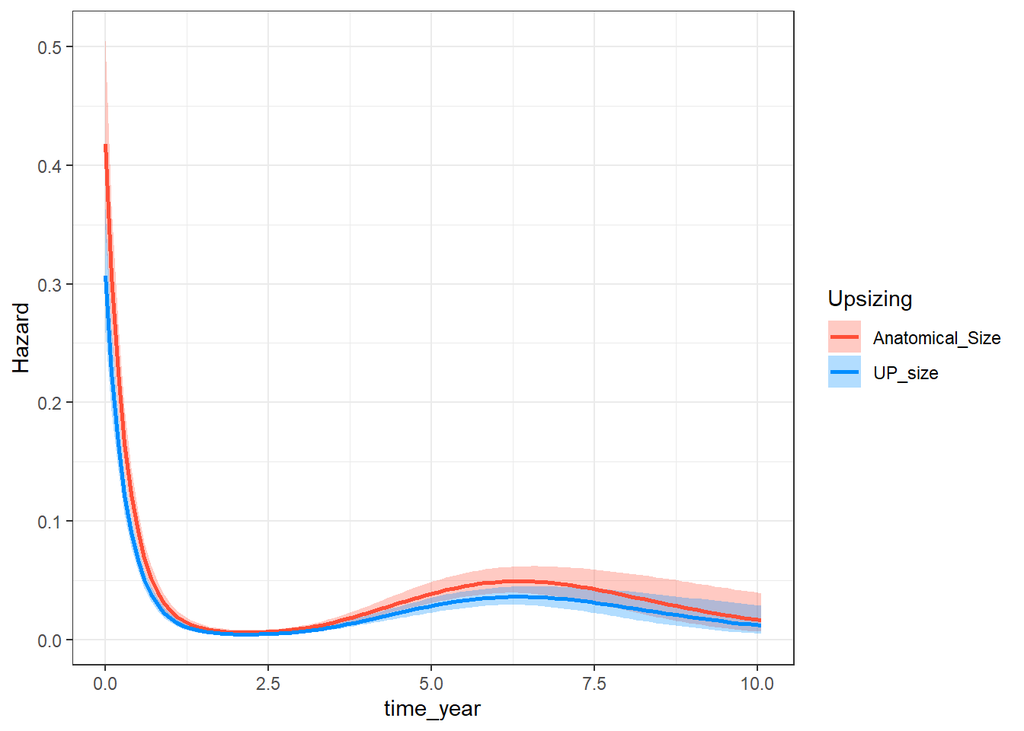

| **Characteristic** | **HR**<sup>1</sup> | **95% CI**<sup>1</sup> | **p-value** |
| --- | --- | --- | --- |
| log10(STS + 1) | 11.2 | 7.57, 16.7 | <0.001 |
| Prosthesis_Anat_Aort_Valve |  |  |  |
| 2x | — | — |  |
| 3x | 1.49 | 1.03, 2.15 | 0.032 |
| Upsizing |  |  |  |
| Anatomical_Size | — | — |  |
| UP_size | 0.83 | 0.64, 1.07 | 0.14 |

<sup>1</sup> HR = Hazard Ratio, CI = Confidence Interval

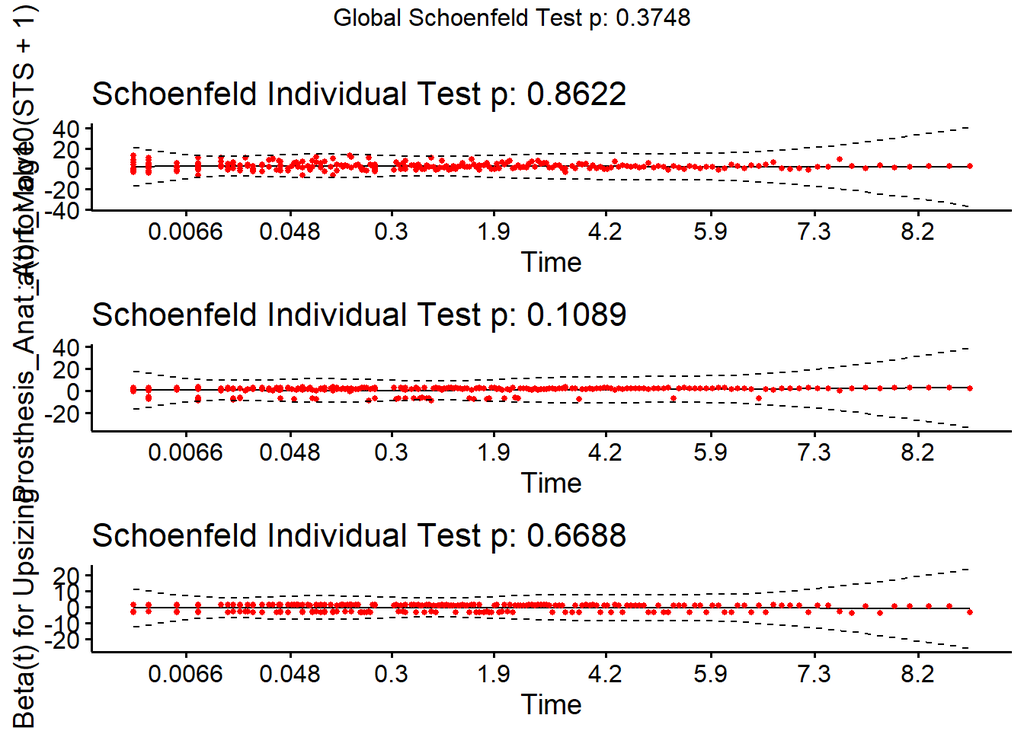

```
## Call:
## concordance.coxph(object = fit_covariance)
##
## n= 1446
## Concordance= 0.7027 se= 0.01768
## concordant discordant     tied.x     tied.y    tied.xy
##     183266      77494        158        399          1
```

```
##             log10(STS + 1) Prosthesis_Anat_Aort_Valve
##                   1.065072                   1.061818
##                   Upsizing
##                   1.003388
```

```
## Analysis of Deviance Table
##  Cox model: response is  surv_object
##  Model 1: ~ log10(STS + 1) + Prosthesis_Anat_Aort_Valve + Upsizing
##  Model 2: ~ log10(STS + 1) + Prosthesis_Anat_Aort_Valve
##    loglik  Chisq Df Pr(>|Chi|)
## 1 -1719.2
## 2 -1720.3 2.1175  1     0.1456
```

# Multivariate Imputation by Chained Equations (MICE)